# Weather anomalies associated with wildfires in the Great Plains

Preliminary analysis

DAM

2021-04-07

# Main take-aways

# Location of fires

The preliminary analysis is limited to the 20 largest fires in the MTBS database from the Northwestern Great Plains EPA Level III ecoregion:

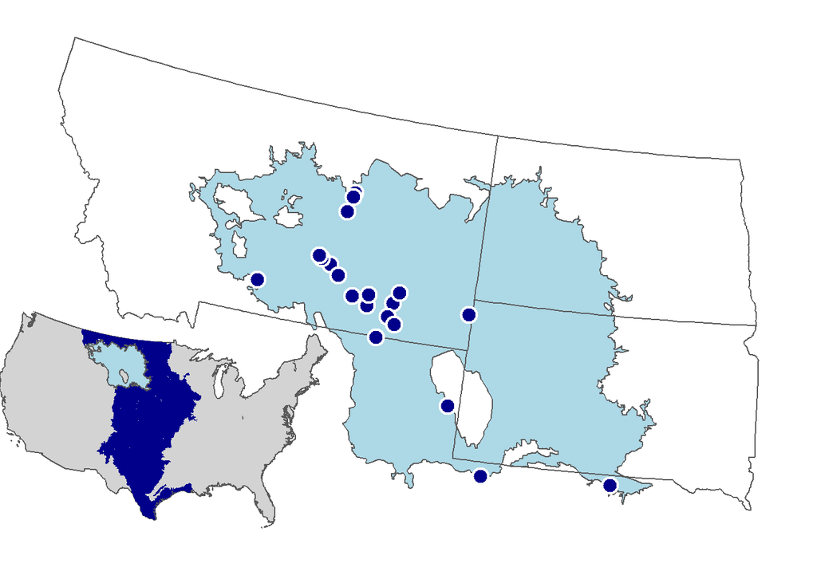

# Day-of conditions relative to ‘normal’

## Methods

1. Determine centroid of each perimeter
2. Define a “weather week” as three days prior to ignition and three days after
3. Fetch historical weather data for the week, 1980-2020, from gridMET data
4. Calculate mean for each variable for each annual weather week
5. Plot day-of conditions relative to distribution of historical values (1980-2020)

## Results

In most of the 20 fires, several variables had consistent relationships relative to ‘normal’ values:

- Vapor Pressure Deficit (VPD) appeared the highest on the day of ignition relative to median values
- Aside from 5 fires with apparently no Burn Index data, BI tended to be higher than normal on days of ignition

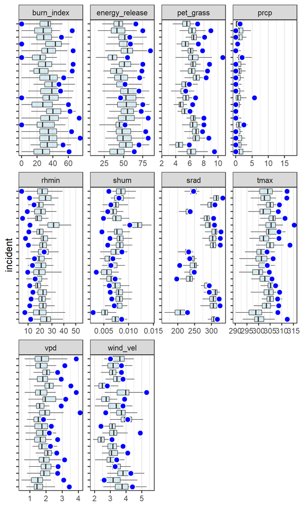

Variables include

| gridMET code | Weather variable |
| --- | --- |
| `burn_index` | Fire behavior (NFRDS) |
| `energy_release` | Energy Release Component (NFRDS) |
| `pet_grass` | Potential Evapotranspiration |
| `prcp` | Daily rainfall |
| `rhmin` | Lowest RH for the day |
| `shum` | Daily mean specific humidity |
| `srad` | Daily mean surface shortwave radiation |
| `tmax` | Daily maximum air temperature (dry bulb) |
| `vpd` | Vapor Pressure Deficit |
| `wind_vel` | Daily mean wind speed |

# Trends in anomalies

Here I’ve calculated the anomaly for each variable as

$$\frac{'Day~of'~value - median}{standard~deviation}$$

This graph summarizes departures of day-of-ignition values from median values, with departure expressed as standard deviations away from the median value.  
The data combine the median and 95% confidence interval of departures for all 20 fires.

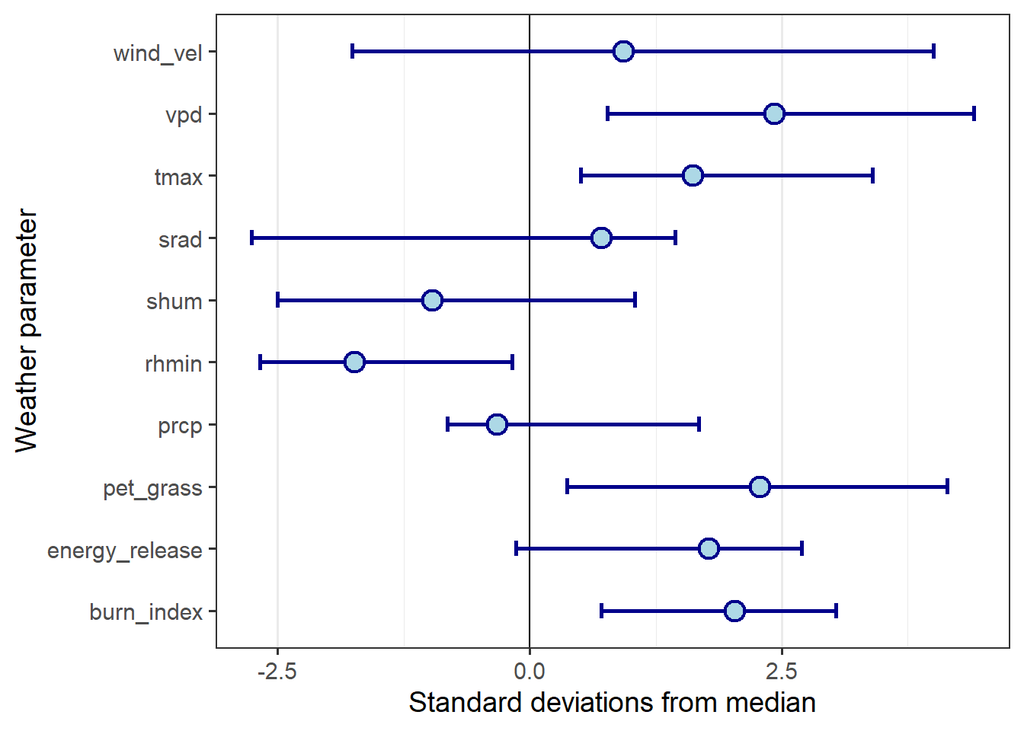

This can be interpreted as the median vapor pressure deficit for these 20 fires was 2.5 standard deviations above normal for the week in which the fire occurred. The variable with the next greatest anomaly was PET. RH had less of an anomaly than might be expected. Of the two NFRDS products included here, BI had a consistently high anomaly and ERC was not signficantly different than normal.

# Next steps

- Expand geographic scope to entire Great Plains region (Dark blue in map)
- Statistical models to identify variable or combination of variables with most consistent anomalies
- Identify seasonal patterns in anomalies
- Identify spatial and temporal changes in the seasonality, frequency, magnitude, and duration of anomalies